# Building Automation And Lighting Overview

# Summary

mmWave radar sensors offer a host of functionality that improve the effectiveness and efficiency of many building automation and lighting applications. The IWR family of radar sensors can be used to reliably and accurately sense the presence or absence of a subjects, count the number occupants in an area, set several areas of observation, determine precise location of persons/objects, determine the direction and speed of a subject and more.

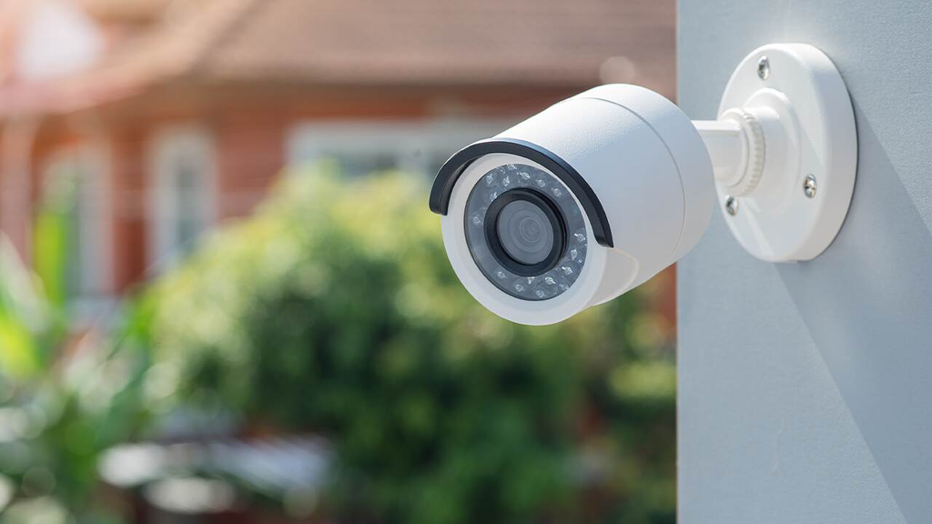

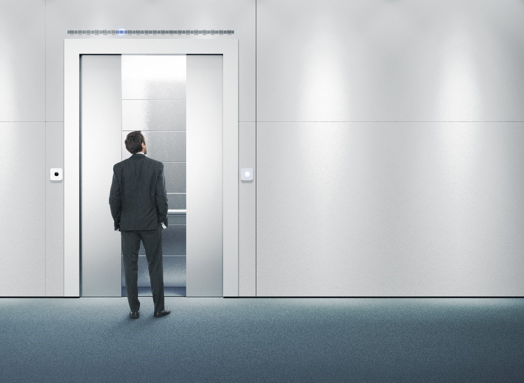

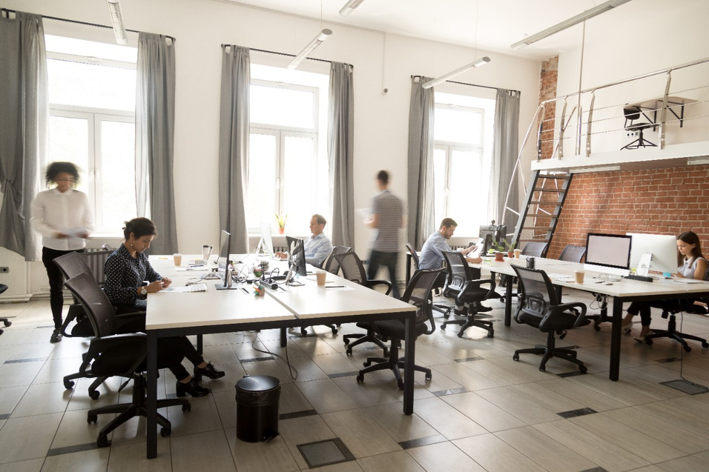

**Commercial and Home Surveillance**

**Automated Doors and Gates Control**

**Indoor Occupany Sensing and Lighting**

Recommended Devices:  
IWR6843  
IWRL6432 (Video Doorbell)

Recommended Devices:  
IWR6843  
IWR6843AOP  
IWRL6432

Recommended Devices:  
IWR6843  
IWR6843AOP  
IWRL6432

## Commercial and Home Surveillance

| Recommended devices | Key Functions | Key challenges overcome by radar |
| --- | --- | --- |
| IWR6843 IWRL6432 | - Presence detection - Motion detection - People counting - Human vs non-human classification - Velocity detection - Fall detection - Localization | - False alarms - Direction of motion - Detection in bright light - Detection in precipitation (rain, snow, and fog) - Multi-zone detection |

### Development Resources

**Example Projects**

- Radar Doorbell (IWRL6432)
- 3D People Counting (IWR6843ISK, IWR6843ODS, IWR6843AOP, or IWR6843L)
- Long Range People Detection (IWR6843ISK)

**Videos**

- [mmWave Radar Sensing for Security and Surveillance](https://training.ti.com/security-and-surveillance-using-iwr-mmwave-sensors)
- [mmWave Radar Sensing Through Rain and Walls](https://training.ti.com/sense-world-ti-mmwave-see-through-rain-and-walls-and-detect-small-objects)

**Experiments**

- Detecting Humans and Filtering False Detection
- Radar Response to Rain

## Automated Doors and Gates Control

| Recommended devices | Key Functions | Key challenges overcome by radar |
| --- | --- | --- |
| IWR6843 IWR6843AOP IWRL6432 | - Presence detection - Motion detection - People counting - Static object detection - Human vs non-human classification - Velocity detection | - False detection - Direction of motion - People counting - Classification |

### Development Resources

**Example Projects**

- Area Scanner (IWR6843ISK, IWR6843ODS, IWR6843AOP, or IWR6843L)
- Automated Doors and Gates (IWR6843ISK, IWR6843ODS, IWR6843AOP, or IWR6843L)
- Indoor Occupancy Sensing (IWRL6432)
- 3D People Counting (IWR6843ISK, IWR6843ODS, IWR6843AOP, or IWR6843L)
- Overhead 3D People Counting (IWR6843AOP, IWR6843ODS)

**Videos**

- [Intelligent automated doors with mmWave sensors](https://training.ti.com/intelligent-automated-doors-ti-mmwave-sensors)
- [Smart building access / touchless control](https://training.ti.com/smart-building-access-touchless-control)
- [People counting for entry ways](https://training.ti.com/3d-people-counting-entryways)

**Experiments**

- Detecting Approaching Objects for Elevator Doors
- Building Occupancy Detection Using mmWave

## Indoor Occupany Sensing and Lighting

| Recommended devices | Key Functions | Key challenges overcome by radar |
| --- | --- | --- |
| IWR6843 IWR6843AOP IWRL6432 | - Presence detection - Motion detection - People counting / tracking - Fall detection - Space occupancy - Localization | - False detection - Fine motion detection - Localization - People counting / tracking - Fall detection |

### Development Resources

**Example Projects**

- Indoor Occupancy Sensing (IWRL6432)
- 3D People Counting (IWR6843ISK, IWR6843ODS, IWR6843AOP, or IWR6843L)
- Overhead 3D People Counting (IWR6843AOP, IWR6843ODS)

**Videos**

- [3D Occupancy Sensing Home and Office](https://training.ti.com/3d-occupancy-sensing-home-and-office)
- [People Counting mmWave Sensors Application Benefits](https://training.ti.com/people-counting-mmwave-sensors-application-benefits)
- [Intelligent Fall Detection using TI mmWave Radar Sensors](https://training.ti.com/intelligent-fall-detection-using-ti-mmwave-radar-sensors)

**Experiments**

- Fall Detection
- Building Occupancy Detection Using mmWave
- People counting through Plastic, Drywall, and Wood

## Certification

- [TI mmWave Radar Device Regulatory Compliance Guide](http://www.ti.com/lit/spracp3)
- TI mmWave Certification Database

## Third Party Resources

- [Designing TI mmWave radar made easier using our third-party ecosystem](https://e2e.ti.com/blogs_/b/industrial_strength/posts/ti-mmwave-radar-made-easy-with-our-third-party-ecosystem)
- [Browse third-party solutions and find the right third-party to meet your needs](https://www.ti.com/tool/MMWAVE-3P-SEARCH)